# Practical Machine Learning

sherranz

22/03/2015

## Overview

We need to predict the manner in which the users did the exercise. We have a large sample set (19622 obs and 160 variables) and we need to predict the “classe” variable in another 20 samples. The plan is:

1. Split data
2. Exploratory data analysis
3. Cross validation and error estimation
4. Estimated out of sample error
5. Fit the model
6. Apply model to validate data

Go ahead!

## 1. Load and split data

First of all, I load and split data. I fix the seed for a reproducible analysis. We have a test data file, then I take 60% for training and 40% for validation.

```r
  require(caret)
  require(rpart)
  require(randomForest)

  localfile<-"pml-training.csv"
  if (!file.exists(localfile)){
    file = "https://d396qusza40orc.cloudfront.net/predmachlearn/pml-training.csv"
    download.file(url = file, destfile = localfile , method = "curl")
  }
  localtestfile<-"pml-testing.csv"
  if (!file.exists(localtestfile)){
    file = "https://d396qusza40orc.cloudfront.net/predmachlearn/pml-testing.csv"
    download.file(url = file, destfile = localtestfile , method = "curl")
  }

  data<-read.table(localfile, sep = ",", header = T, na.strings = "?")
  datatest<-read.table(localtestfile, sep = ",", header = T, na.strings = "?")

  set.seed(220470)
  inTrain <- createDataPartition(y=data$classe, p=0.6, list=FALSE)
  training <- data[inTrain,]
  validate <- data[-inTrain,]
```

## 2. Exploratory data analysis

### 2.1. Near Zero Vars

The nearZeroVar function show a hundred of near zero vars. I don’t want to fight with them, so I remove them. I remove columns 1 to 7, they aren’t interesting now.

```r
  nzvs<-nearZeroVar(training, saveMetrics = T)
  sum(nzvs$nzv)
```

```
## [1] 101
```

```r
  training<-training[,-c(1:7, which(nzvs$nzv))]
  validate<-validate[,-c(1:7, which(nzvs$nzv))]
```

### 2.2. Outliers

There are some ways to find outliers, I did it painting some plots. I found a couple of outliers. I removed them.

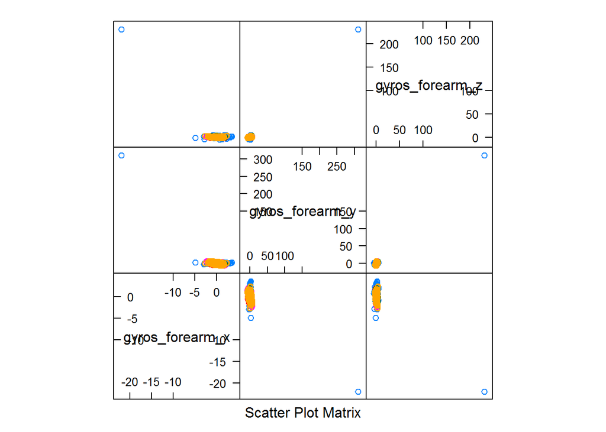

```r
  featurePlot(training[,44:46], training[,53], plot="pairs")
```

```r
  outlier<-which(training$gyros_forearm_y>250)
  outlier
```

```
## [1] 3215
```

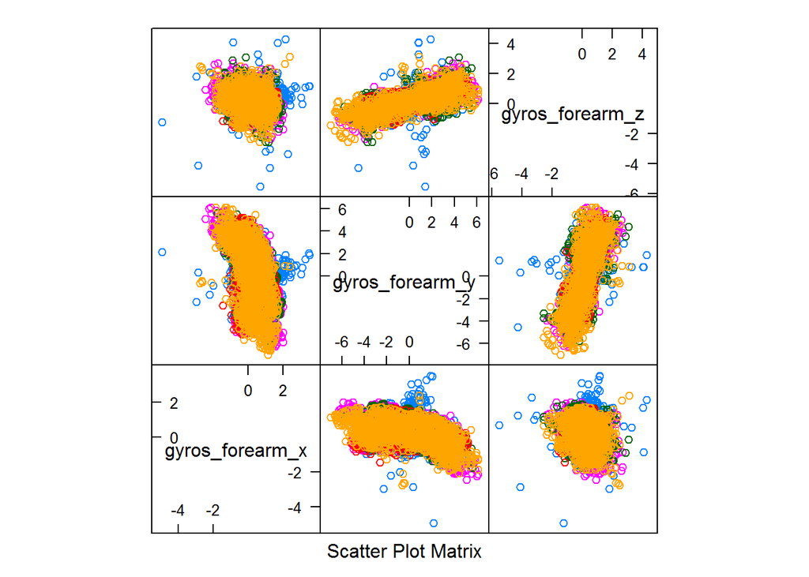

```r
  training<-training[-outlier,]
  featurePlot(training[,44:46], training[,53], plot="pairs")
```

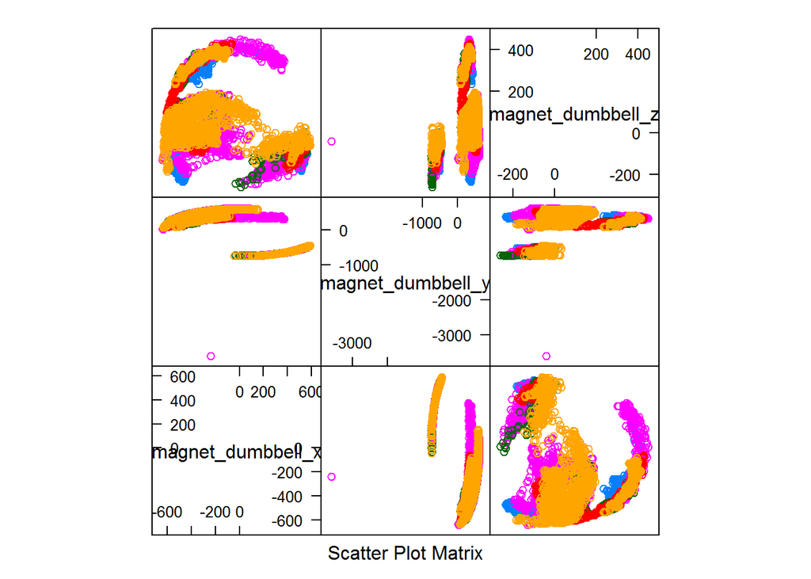

```r
  featurePlot(training[,37:39], training[,53], plot="pairs")
```

```r
  outlier<-which(training$magnet_dumbbell_y < (-3000))
  outlier
```

```
## [1] 5569
```

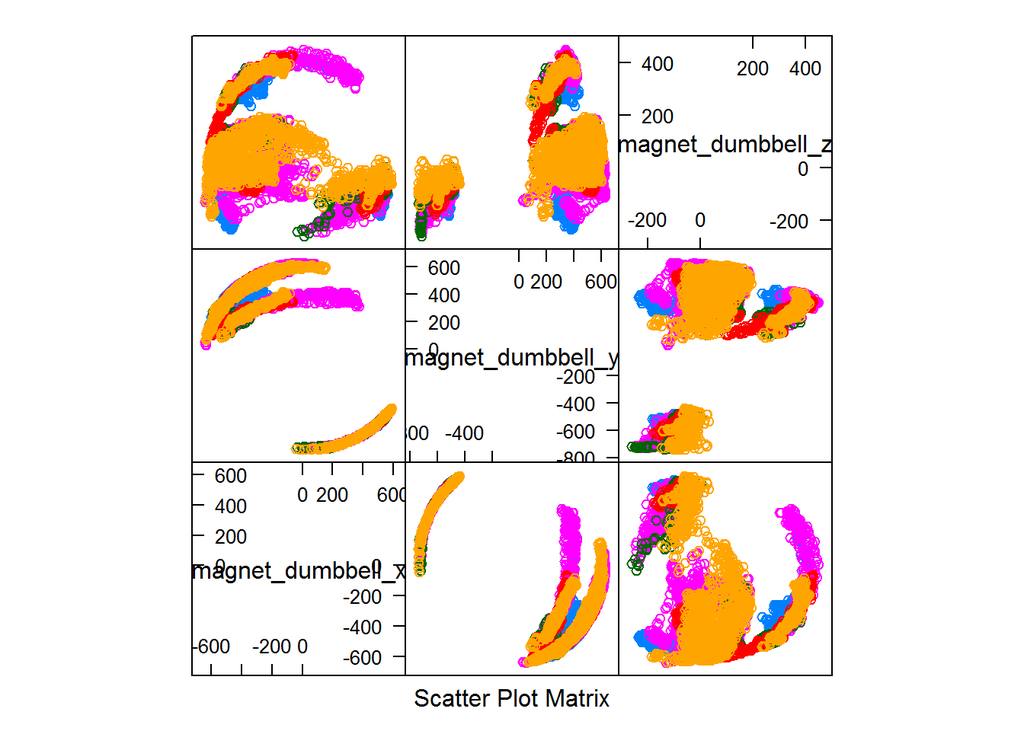

```r
  training<-training[-outlier,]
  featurePlot(training[,37:39], training[,53], plot="pairs")
```

### 2.3. Feature selection

Running principal components analysis show as we can get more than 95% of total variation with only 9 variables, so this is my selection

```r
  pca<-prcomp(training[,-53])
  summary(pca)
```

```
## Importance of components:
##                             PC1      PC2      PC3      PC4      PC5
## Standard deviation     598.4266 537.5447 471.0904 377.8946 355.2702
## Proportion of Variance   0.2627   0.2120   0.1628   0.1048   0.0926
## Cumulative Proportion    0.2627   0.4747   0.6375   0.7423   0.8349
##                              PC6       PC7       PC8       PC9      PC10
## Standard deviation     253.23249 200.73921 172.22821 158.09110 118.52610
## Proportion of Variance   0.04705   0.02956   0.02176   0.01834   0.01031
## Cumulative Proportion    0.88197   0.91153   0.93329   0.95163   0.96193
##                            PC11    PC12     PC13     PC14     PC15
## Standard deviation     96.61112 89.6647 76.70719 68.48530 61.70237
## Proportion of Variance  0.00685  0.0059  0.00432  0.00344  0.00279
## Cumulative Proportion   0.96878  0.9747  0.97900  0.98244  0.98523
##                            PC16     PC17     PC18     PC19     PC20
## Standard deviation     56.52649 53.07549 49.33795 48.23237 41.45018
## Proportion of Variance  0.00234  0.00207  0.00179  0.00171  0.00126
## Cumulative Proportion   0.98758  0.98964  0.99143  0.99314  0.99440
##                            PC21     PC22     PC23     PC24     PC25
## Standard deviation     37.22346 34.56570 32.14472 30.42872 25.19756
## Proportion of Variance  0.00102  0.00088  0.00076  0.00068  0.00047
## Cumulative Proportion   0.99541  0.99629  0.99705  0.99773  0.99819
##                            PC26     PC27     PC28     PC29     PC30
## Standard deviation     23.18386 21.64832 20.51501 17.17226 14.78637
## Proportion of Variance  0.00039  0.00034  0.00031  0.00022  0.00016
## Cumulative Proportion   0.99859  0.99893  0.99924  0.99946  0.99962
##                            PC31    PC32    PC33    PC34    PC35    PC36
## Standard deviation     13.71939 9.85748 7.58848 7.22079 6.61412 6.19500
## Proportion of Variance  0.00014 0.00007 0.00004 0.00004 0.00003 0.00003
## Cumulative Proportion   0.99975 0.99982 0.99987 0.99991 0.99994 0.99997
##                           PC37    PC38    PC39  PC40  PC41  PC42   PC43
## Standard deviation     3.70579 3.42382 3.31525 2.121 1.942 1.075 0.5043
## Proportion of Variance 0.00001 0.00001 0.00001 0.000 0.000 0.000 0.0000
## Cumulative Proportion  0.99998 0.99998 0.99999 1.000 1.000 1.000 1.0000
##                          PC44   PC45   PC46   PC47   PC48   PC49   PC50
## Standard deviation     0.4163 0.3606 0.3147 0.3117 0.2425 0.1935 0.1848
## Proportion of Variance 0.0000 0.0000 0.0000 0.0000 0.0000 0.0000 0.0000
## Cumulative Proportion  1.0000 1.0000 1.0000 1.0000 1.0000 1.0000 1.0000
##                          PC51    PC52
## Standard deviation     0.1013 0.03567
## Proportion of Variance 0.0000 0.00000
## Cumulative Proportion  1.0000 1.00000
```

```r
  preProc<-preProcess(training[,-53], method="pca", pcaComp = 9)
  trainPCA<-predict(preProc, training[,-53])
  trainPCA<-cbind(trainPCA, classe=training[,53])
```

## 3. Cross Validation and error estimation

I prepared a bunch of splits for the training data, in order to validate the model.

```r
  splits<- matrix(nrow = 20, ncol = 9421)
  for (i in 1:20){
    forValidate <- createDataPartition(y=training$classe, p=0.8, list=FALSE)
    splits[i,]<-forValidate
  }
```

A random forest must works fine in this case. I use cross validation split.

```r
  totalOK<-0
  for (i in 1:20){
    trainPCA_tr<-trainPCA[splits[i,], ]
    trainPCA_va<-trainPCA[-splits[i,], ]
    model<-train(classe~., data=trainPCA_tr, method="rf", PROX=TRUE)
    prediction<-predict(model, newdata = trainPCA_va)
    prOK<-sum(prediction==trainPCA_va$classe)
    prKO<-sum(prediction!=trainPCA_va$classe)
    print(paste(date(), " CV", i, ", OK=", prOK, ", KO=", prKO, ", accuracy=", prOK/dim(trainPCA_va)[1], sep = ""))
    totalOK<-totalOK + prOK
  }
```

```
## [1] "Sun Mar 22 10:14:09 2015 CV1, OK=2181, KO=172, accuracy=0.926901827454314"
## [1] "Sun Mar 22 10:23:57 2015 CV2, OK=2169, KO=184, accuracy=0.921801954951126"
## [1] "Sun Mar 22 10:33:49 2015 CV3, OK=2181, KO=172, accuracy=0.926901827454314"
## [1] "Sun Mar 22 10:43:37 2015 CV4, OK=2161, KO=192, accuracy=0.918402039949001"
## [1] "Sun Mar 22 10:53:24 2015 CV5, OK=2170, KO=183, accuracy=0.922226944326392"
## [1] "Sun Mar 22 11:03:10 2015 CV6, OK=2186, KO=167, accuracy=0.929026774330642"
## [1] "Sun Mar 22 11:12:59 2015 CV7, OK=2180, KO=173, accuracy=0.926476838079048"
## [1] "Sun Mar 22 11:22:44 2015 CV8, OK=2191, KO=162, accuracy=0.93115172120697"
## [1] "Sun Mar 22 11:32:34 2015 CV9, OK=2161, KO=192, accuracy=0.918402039949001"
## [1] "Sun Mar 22 11:42:39 2015 CV10, OK=2153, KO=200, accuracy=0.915002124946876"
## [1] "Sun Mar 22 11:52:56 2015 CV11, OK=2178, KO=175, accuracy=0.925626859328517"
## [1] "Sun Mar 22 12:03:20 2015 CV12, OK=2165, KO=188, accuracy=0.920101997450064"
## [1] "Sun Mar 22 12:14:50 2015 CV13, OK=2175, KO=178, accuracy=0.92435189120272"
## [1] "Sun Mar 22 12:24:42 2015 CV14, OK=2159, KO=194, accuracy=0.91755206119847"
## [1] "Sun Mar 22 12:34:30 2015 CV15, OK=2176, KO=177, accuracy=0.924776880577986"
## [1] "Sun Mar 22 12:44:13 2015 CV16, OK=2187, KO=166, accuracy=0.929451763705907"
## [1] "Sun Mar 22 12:54:00 2015 CV17, OK=2180, KO=173, accuracy=0.926476838079048"
## [1] "Sun Mar 22 13:03:51 2015 CV18, OK=2167, KO=186, accuracy=0.920951976200595"
## [1] "Sun Mar 22 13:13:43 2015 CV19, OK=2172, KO=181, accuracy=0.923076923076923"
## [1] "Sun Mar 22 13:23:31 2015 CV20, OK=2177, KO=176, accuracy=0.925201869953251"
```

```r
  accMean<-totalOK/20/dim(trainPCA_va)[1]
  print(paste("Accuracy mean:", accMean))
```

```
## [1] "Accuracy mean: 0.923693157671058"
```

## 4. Estimated out of sample error

THE ESTIMATED OUT OF SAMPLE ERROR is about 7.6% (0.0763068).

## 5. Fit the model

The final model is

```r
  final_model<-train(classe~., data=trainPCA, method="rf", prox=TRUE)
  print(final_model)
```

```
## Random Forest
##
## 11774 samples
##     9 predictor
##     5 classes: 'A', 'B', 'C', 'D', 'E'
##
## No pre-processing
## Resampling: Bootstrapped (25 reps)
##
## Summary of sample sizes: 11774, 11774, 11774, 11774, 11774, 11774, ...
##
## Resampling results across tuning parameters:
##
##   mtry  Accuracy   Kappa      Accuracy SD  Kappa SD
##   2     0.9107744  0.8871324  0.004512396  0.005652584
##   5     0.9038377  0.8783740  0.005253550  0.006581336
##   9     0.8934426  0.8652244  0.006940233  0.008722017
##
## Accuracy was used to select the optimal model using  the largest value.
## The final value used for the model was mtry = 2.
```

## 6. Apply model to validate data

Now it’s time to apply the model to our validate data

```r
  validatePCA<-predict(preProc, validate[,-53])
  validatePCA<-cbind(validatePCA, classe=validate[,53])
  final_prediction<-predict(final_model, newdata = validatePCA)
  final_prOK<-sum(final_prediction==validatePCA$classe)
  final_prKO<-sum(final_prediction!=validatePCA$classe)
  final_acc<-final_prOK/dim(validatePCA)[1]
  print(paste("Final prediction, OK=", final_prOK, ", KO=", final_prKO, ", accuracy=", final_acc, sep = ""))
```

```
## [1] "Final prediction, OK=7346, KO=500, accuracy=0.936273260260005"
```

Real out of sample error is 0.0637267.